# My experience using the nf-core/ampliseq pipeline for metabarcoding analysis

Charlotte Berthelier

cberthelier@sb-roscoff.fr

September 29, 2026

## Overview of Metabarcoding

`Metabarcoding` is a molecular technique used to **identify and quantify the diversity of organisms in environmental samples** by amplifying and sequencing specific genetic markers (**barcodes**) from environmental DNA (**eDNA**).

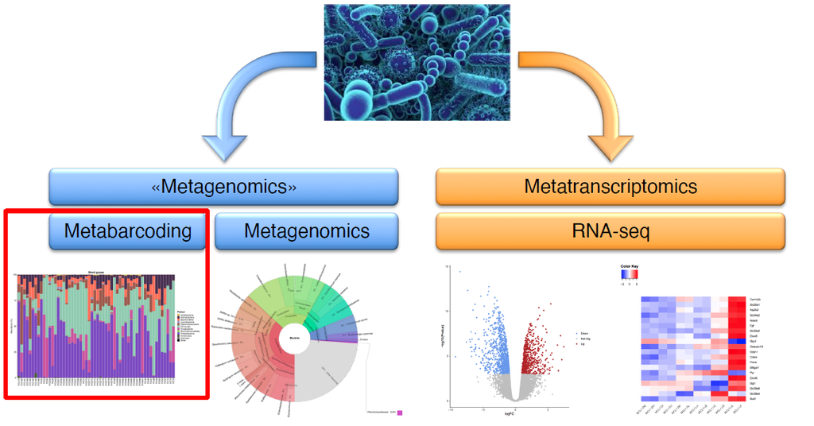

## Metabarcoding Workflow

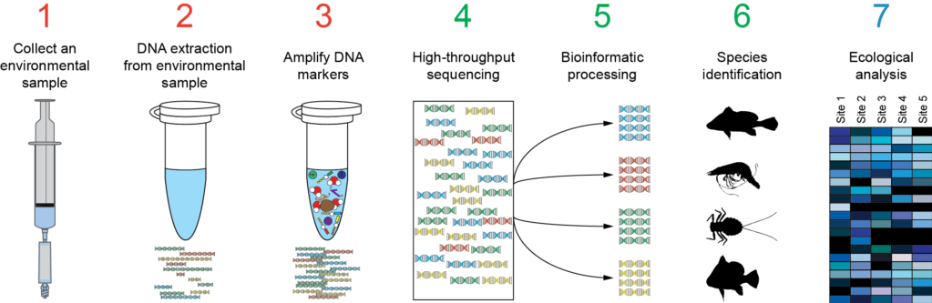

**Environmental genomics**

1. **Collect samples** (water, sediment, tissue) containing eDNA from various organisms.
2. **Extract environmental DNA** from the samples.
3. PCR Amplification of specific **genetic markers** (e.g., 16S rRNA for bacteria, 18S rRNA for eukaryotes, COI for animals).
4. **High-throughput sequencing technologies** (e.g., Illumina, PacBio) to sequence the amplified DNA.
5. Process **sequencing data** to identify and quantify different species.

## Advantages of using `nf-core pipelines`

- Standardized Workflows:

  Nf-core provides standardized, **community-curated workflows** for analyzing data, ensuring **consistency and reproducibility**.
- Nextflow Integration:

  Built on **`Nextflow`**, a powerful workflow management system, allowing for scalable and portable data analysis.

## Why `nf-core/ampliseq?`

[figure not shown]

* **Pre-configured bioinformatics analysis workflow for amplicon sequencing**, supporting multiple input formats.

* Developed and maintained by a global community of researchers and bioinformaticians, ensuring continuous **improvement and updates**.

* Comprehensive **documentation and tutorials** make it accessible for users of all skill levels.

## Setting up the pipeline

**Relative requirements to launch ampliseq on the BioPipes VM**

- Software dependencies: Nextflow
- VM config nextflow file: `ampliseq_vm.config` *(or your own `nextflow.config`)* to define parameters specific to the compute environment of the **BioPipes VM** for nf-core pipelines (such as resourceLimits and partitions).
- Need 8 CPU minimum to run

**Files needed:**

- **FastQ raw files** `.fastq.gz`
- **Samplesheet** `.tsv`, `.csv` or `.yml` file listing samples and paths to FastQ files.
- **Parameters file** `.yml` file containing pipeline specific configurations (genomic references, tools, etc.).
- **Bash script** `.sh` to submit the ampliseq pipeline to a SLURM cluster.

## Samplesheet input

The sample sheet file can be tab-separated (`.tsv`), comma-separated (`.csv`), or in YAML format (`.yml`/`.yaml`) and can have two to four columns/entries with the following headers:

| `sampleID` | `forwardReads` | `reverseReads` | `run` |
| --- | --- | --- | --- |
| required | required | *optional* | *optional* |
| Unique sample identifiers | Paths to (forward) reads zipped FastQ files | Paths to reverse reads zipped FastQ files, required if the data is paired-end | If the data was produced by multiple sequencing runs |

## Samplesheet input *(example)*

`samplesheet.tsv`

| `sampleID` | `run` | `forwardReads` | `reverseReads` |
| --- | --- | --- | --- |
| S11B | run_01 | data/raw/S11B_R1.fastq.gz | data/raw/S11B_R2.fastq.gz |
| S1B | run_01 | data/raw/S1B_R1.fastq.gz | data/raw/S1B_R2.fastq.gz |
| S2B | run_01 | data/raw/S2B_R1.fastq.gz | data/raw/S2B_R2.fastq.gz |
| S2S | run_01 | data/raw/S2S_R1.fastq.gz | data/raw/S2S_R2.fastq.gz |
| … | … | … | … |

## Parameter file *(example)*

`params_ampliseq.yaml`

```yaml
input: "input/samplesheet.tsv"
FW_primer: "GTGYCAGCMGCCGCGGTAA"
RV_primer: "CCGYCAATTYMTTTRAGTTT"
outdir: "output/ampliseq"

# Read trimming and quality filtering
max_ee: 2
trunclenf: 200
trunclenr: 200
trunc_qmin: 2

# Amplicon Sequence Variants (ASV) calculation
sample_inference: "pooled"

# Taxonomic db
dada_ref_taxonomy: "pr2=5.0.0"

# Asv filtering
min_frequency: 2
min_samples: 3

# Generic options
# Max job request
max_cpus: 32
max_memory: "100.GB"
max_time: "720.h"
```

https://nf-co.re/ampliseq/2.18.0/parameters/

[figure not shown]

## Submit the ampliseq pipeline to a slurm cluster *(example)*

Using bash script: `ampliseq.sh`

```bash
#!/bin/bash

nextflow run nf-core/ampliseq \
  -bg \
  -r 2.18.0 \
  -profile docker \
  -c "practicals/ampliseq_files/ampliseq_vm.config" \
  -params-file practicals/ampliseq_files/ampliseq_parameters_simple.yaml
```

```
# Path to files:
# ├── ampliseq.sh
# ├── practicals
# │   └── ampliseq_files
# │      ├── samplesheet.tsv
# │      ├── ampliseq_vm.config
# │      └── ampliseq_parameters_simple.yaml
```

## Running time

Approximately 30 minutes for ANF training data

The longest step being the taxonomic assignment!

[figure not shown]

## Output files (1)

- `summary_report.html`: pipeline summary report as standalone HTML file that can be viewed in your web browser. *Example [here](https://nf-core-awsmegatests.s3-eu-west-1.amazonaws.com/ampliseq/results-9c52c22f17179b9bd5cb2621c05ec3a931adcb02/summary_report/summary_report.html).*

[figure not shown]

## Output files (2)

- `ASV_tax.*.tsv`: Taxonomic classification for each ASV sequence.

**ASV_tax.pr2_5_0_0** in our *example*

| `ASV_ID` | `Domain` | `Supergroup` | `Division` | `Subdivision` | `Class` | `Order` |
| --- | --- | --- | --- | --- | --- | --- |
| b7db | Bacteria | PANNAM | Proteobacteria | Proteobacteria_X | Gammaproteobacteria | Alteromonadales |
| e01e | Bacteria | FCB | Bacteroidetes | Bacteroidetes_X | Bacteroidia | Flavobacteriales |

| `Family` | `Genus` | `Species` | `Confidence` | `Sequence` |
| --- | --- | --- | --- | --- |
| Marinobacteraceae | Marinobacter | Marinobacter_sp. | 1 | TACGGAGGGTGCAA… |
| Flavobacteriaceae | Flavobacterium | Flavobacterium_sp. | 0.99 | TACGGAGGATCCAAGCG… |

## Output files (3)

- `ASV_table.tsv`: summary of the Amplicon Sequence Variants (ASVs) detected in each of your sample.

| `ASV_ID` | `A120_A` | `A120_B` | `A141_A` | `A141_B` | `...` |
| --- | --- | --- | --- | --- | --- |
| b7db | 2841 | 1118 | 614 | 442 | … |
| bab5 | 9163 | 7036 | 19075 | 13799 | … |

## Output files (4)

After preprocessing (primer trimming, QC) & ASV inference with DADA2, the **QIIME2 analysis** goals are :

1. Taxonomic profiling
2. Diversity (α & β)
3. Differential abundance
4. Visual summaries (barplots, rarefaction curves, etc.)

## Output files (4.1) - Abundance and relative abundance

The abundance tables are the final data for further downstream analysis and visualisations.

| Output | Description |
| --- | --- |
| **Absolute abundance table** | Raw ASV counts per sample |
| **Relative abundance table** | Normalized counts (e.g. proportions per sample) |

- Useful for comparing taxa abundances across samples (.tsv)
- These tables feed into plots & statistical tests

## Output files (4.2) - Alpha diversity & rarefaction curves

Alpha diversity measures the species diversity within samples.

- **Rarefaction curves**: check sampling depth sufficiency; plot number of observed features vs sequencing depth per sample
- **Alpha diversity indices**: metrics like Observed ASVs, Shannon, Simpson, Faith’s PD etc.

Purpose: evaluate within-sample diversity; check outliers, effect of filtering

Beta diversity measures the species community differences between samples.

- **Distance metrics** (e.g. Bray-Curtis, UniFrac if phylogenetic tree available)
- **Ordination plots** (PCoA, NMDS) to visualise differences between samples/groups
- **Permutational tests** (e.g. PERMANOVA / Adonis) to assess significance of grouping

## Output files (4.4) - Interactive barplots

- Barplots of taxonomic composition (e.g. phylum, genus) per sample or group
- Interactive version: allows zooming, selection of taxa, collapsing taxonomic levels
- Helps visually assess major community members and compare across conditions

## Output files (4.5) - Differential abundance

- **ANCOM** (Analysis of Composition of Microbiomes) or **ANCOM-BC** (with Bias Correction)

Aim: identify taxa (ASVs or higher level) with significantly different abundance between groups

**Note**

There are many others output files, I let you investigate them!

Complete list [here](https://nf-co.re/ampliseq/2.14.0/docs/output)

## And if you have a looooooot of data

Instead of using the **ANF MetaBioDiv VM**, you can use the **IFB core cluster** directly.

- 🖥️ VM

> **Simple & convenient**  
> Pre-configured environments  
> Good for small / quick analyses  
> ⚠️ Save your results before shutting down!
- 🚀 Cluster

> **Power & scalability**  
> High computing performance  
> Designed for large datasets  
> Persistent shared storage  
> Run jobs with SLURM

**Tip**

A lot of data? A thesis / long-time project? → Use the cluster!

## Useful links

**There’s no shame in getting help!**

- [nf-core/ampliseq website](https://nf-co.re/ampliseq/2.12.0/)
- [ABiMS Cluster Documentation - SLURM user guide](https://abims-sbr.gitlab.io/cluster/doc/slurm/slurm_user_guide/)
- [nf-core/configs: ABiMS Configuration](https://github.com/nf-core/configs/blob/master/docs/abims.md)

**Thank you for your attention!**